# 数据分析岗位需求调查研究报告

-仅研究：北京、上海、广州、深圳和杭州地区  
-数据来源：八爪鱼采集器->boss直聘/拉勾  
-采集时间：2022/3/19  
-报告时间：2022/3/23

**提出问题**：

- 招聘公司统计-到底是哪些公司招聘数据分析岗位多？
- 薪资水平统计-该岗位在不同城市的平均薪资水平？
  - 不同经验要求下的平均薪资水平
  - 不同学历要求下的平均薪资水平
  - 不同学历要求下，随着经验要求的提高，平均薪资水平的变化

**分析步骤**：

- 导入数据、数据清洗（缺失值）
- 数据统计与分析
- 岗位关键词与福利一览

## 一、导入数据

```python
#数据处理库
import numpy as np
import pandas as pd
```

```python
#导入数据
path = 'C:/Users/Administrator/Desktop/lagou_job.csv'
data = pd.read_csv(path,encoding = 'utf-8')
```

```python
#查看数据
#显示所有列（如果不设置会有列被隐藏掉），第二个参数是显示的列数。如果是行：display.max_rows
pd.set_option('display.max_columns',None)
data.head(5)
```

|  | 公司 | 岗位 | 地点 | 薪资 | 经验要求 | 学历 | 公司详情 | 关键词 | 描述 |
| --- | --- | --- | --- | --- | --- | --- | --- | --- | --- |
| 0 | 汽车之家 | 数据分析师（资讯中心） | 北京 | 20-30K | 3-5年 | 本科 | 互联网已上市1000-9999人 | ExcelSQLHive | 节日福利，股票期权，定期体检，补充医疗保险，年终奖，员工旅游，零食下午茶，餐补，交通补助，带... |
| 1 | 赤子城 | 社交数据分析师 | 北京 | 18-35K | 3-5年 | 本科 | 互联网已上市500-999人 | SQL方差分析回归分析多元统计分析聚类分析决策树SparkKafka | 额外假期，七险一金，节日福利，带薪年假，零食下午茶，股票期权，绩效奖金，全勤奖，补充医疗保险... |
| 2 | 360集团 | 数据分析师 | 北京 | 12-20K | 3-5年 | 本科 | 互联网D轮及以上1000-9999人 | PythonExcel | 餐补，交通补助，免费班车，通讯补贴 |
| 3 | 网易 | 高级/资深数据分析师 | 北京 | 20-40K | 3-5年 | 本科 | 移动互联网已上市10000人以上 | 数据分析数据挖掘商业分析经营数据PythonSPSSSASSQL | 带薪年假，节日福利，年终奖，五险一金，补充医疗保险，免费班车，全勤奖，定期体检，包吃 |
| 4 | 途游游戏 | 数据分析师 | 北京 | 11-20K | 不限 | 本科 | 游戏不需要融资1000-9999人 | 数据分析数据挖掘 | 股票期权，定期体检，节日福利，餐补，全勤奖，零食下午茶，交通补助，五险一金，年终奖，员工旅游... |

```python
data.columns
```

```
Index(['公司', '岗位', '地点', '薪资', '经验要求', '学历', '公司详情', '关键词', '描述'], dtype='object')
```

```python
#缺失值检测函数
def null_value_check(data):
    '''输入：pandas数组'''
    '''输出：每一列的缺失值情况'''
    for i in data.columns:
        print(i,'列缺失值个数为：',data[i].isnull().sum())
```

```python
#检查一下有没有缺失值
null_value_check(data)
```

```
公司 列缺失值个数为： 0
岗位 列缺失值个数为： 0
地点 列缺失值个数为： 0
薪资 列缺失值个数为： 0
经验要求 列缺失值个数为： 0
学历 列缺失值个数为： 0
公司详情 列缺失值个数为： 0
关键词 列缺失值个数为： 0
描述 列缺失值个数为： 0
```

```python
#统计公司数据
company = data['公司'].value_counts()
company
```

```
阿里巴巴集团     23
腾讯         21
BOSS直聘     15
北京字节跳动     15
蚂蚁金服       14
           ..
天空岛信息科技     1
奕格          1
泰案联         1
360数科       1
普渡科技        1
Name: 公司, Length: 657, dtype: int64
```

```python
#排名前二十的公司
com1 = company.iloc[:20]
com1
```

```
阿里巴巴集团        23
腾讯            21
BOSS直聘        15
北京字节跳动        15
蚂蚁金服          14
货拉拉科技         13
京东集团          12
小米             8
快手             8
滴滴             8
百度             8
华为             7
阿里集团           6
美团             6
顺丰科技           6
拼多多            6
蚂蚁集团           6
携程集团           6
京东世纪贸易有限公司     5
今日头条           5
Name: 公司, dtype: int64
```

## 二、 统计分析

#### （1）招聘公司统计

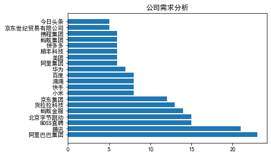

```python
#导包
import matplotlib.pyplot as plt

# 这两行代码解决中文显示的问题
plt.rcParams['font.sans-serif'] = ['SimHei']
plt.rcParams['axes.unicode_minus'] = False

company = com1.index
number = com1.values

plt.barh(company, number) # 横放条形图函数 barh
plt.title('公司需求分析')

plt.show()
```

从公司需求分析可以看出，对数据分析这一岗位需求量多的基本上是互联网企业。  
其中，阿里、腾讯、boss直聘、字节跳动对数据分析人才需求最多。

#### （2）薪资水平统计

**不同地区薪资水平情况**

```python
place = data['地点'].value_counts()
place.values
```

```
array([214, 213, 198, 191, 172], dtype=int64)
```

```python
import pyecharts.charts as pyec
x = list(place.index)
y = place.values.tolist()#array数组转为list
bar=pyec.Bar()
bar.add_xaxis(x)
bar.add_yaxis('数量',y_axis=y)
bar.render_notebook()
```

薪资这一列的数据格式我们需要作简单处理，这里选取平均数作为每个岗位的薪资水平。

```python
data['薪资'] #查看薪资数据格式
```

```
0      20-30K
1      18-35K
2      12-20K
3      20-40K
4      11-20K
        ...
983    15-30K
984    20-40K
985    30-45K
986    25-40K
987    20-40K
Name: 薪资, Length: 988, dtype: object
```

```python
#这里计算的是每个岗位数据的平均薪资，取平均。
def salary_count(x):
    x_min,x_max = x.split('-')  #获取-两边的最大最小值
    x_min = int(x_min)*1000
    x_max = int(x_max.replace('K','000')) #截取字符串，把k改成000，将字符串转化为数字
    if x_min == 0:
        x_min = 1    #除数不能为0
    return np.mean([x_min,x_max])
```

```python
data['薪资'] = data['薪资'].apply(salary_count)
```

```python
data.head(5)
```

|  | 公司 | 岗位 | 地点 | 薪资 | 经验要求 | 学历 | 公司详情 | 关键词 | 描述 |
| --- | --- | --- | --- | --- | --- | --- | --- | --- | --- |
| 0 | 汽车之家 | 数据分析师（资讯中心） | 北京 | 25000.0 | 3-5年 | 本科 | 互联网已上市1000-9999人 | ExcelSQLHive | 节日福利，股票期权，定期体检，补充医疗保险，年终奖，员工旅游，零食下午茶，餐补，交通补助，带... |
| 1 | 赤子城 | 社交数据分析师 | 北京 | 26500.0 | 3-5年 | 本科 | 互联网已上市500-999人 | SQL方差分析回归分析多元统计分析聚类分析决策树SparkKafka | 额外假期，七险一金，节日福利，带薪年假，零食下午茶，股票期权，绩效奖金，全勤奖，补充医疗保险... |
| 2 | 360集团 | 数据分析师 | 北京 | 16000.0 | 3-5年 | 本科 | 互联网D轮及以上1000-9999人 | PythonExcel | 餐补，交通补助，免费班车，通讯补贴 |
| 3 | 网易 | 高级/资深数据分析师 | 北京 | 30000.0 | 3-5年 | 本科 | 移动互联网已上市10000人以上 | 数据分析数据挖掘商业分析经营数据PythonSPSSSASSQL | 带薪年假，节日福利，年终奖，五险一金，补充医疗保险，免费班车，全勤奖，定期体检，包吃 |
| 4 | 途游游戏 | 数据分析师 | 北京 | 15500.0 | 不限 | 本科 | 游戏不需要融资1000-9999人 | 数据分析数据挖掘 | 股票期权，定期体检，节日福利，餐补，全勤奖，零食下午茶，交通补助，五险一金，年终奖，员工旅游... |

可以看到薪资一列已经处理为数字格式。  
接下来计算按城市分组后的平均薪资水平。

```python
mean_salary = data.groupby('地点')['薪资'].mean()
mean_salary
```

```
地点
上海    20888.888889
北京    24948.598131
广州    14395.348837
杭州    20136.150235
深圳    21510.471204
Name: 薪资, dtype: float64
```

```python
#这里是把值转为list
mean_salary_values = mean_salary.values.tolist()
```

```python
mean_salary_index = list(mean_salary.index)
mean_salary_index
```

```
['上海', '北京', '广州', '杭州', '深圳']
```

```python
bar=pyec.Bar()
bar.add_xaxis(mean_salary_index)
bar.add_yaxis('平均工资',mean_salary_values)
bar.render_notebook()
```

**不同经验要求平均薪资情况**

```python
experience_mean_salary = data.groupby('经验要求')['薪资'].mean()
experience_mean_salary
```

```
经验要求
1-3年     15543.408360
10年以上    47000.000000
1年以内      9309.523810
3-5年     22852.303523
5-10年    33438.461538
不限       15574.675325
Name: 薪资, dtype: float64
```

```python
#这里更改了一下索引顺序，按照经验水平进行排序。
experience_mean_salary = experience_mean_salary.reindex(['不限','1年以内','1-3年','3-5年','5-10年','10年以上'])
```

```python
bar1=pyec.Bar()
bar1.add_xaxis(list(experience_mean_salary.index))
bar1.add_yaxis('平均工资',experience_mean_salary.values.tolist())
bar1.render_notebook()
```

**不同学历要求平均薪资情况**

```python
education_mean_salary = data.groupby('学历')['薪资'].mean()
education_mean_salary
```

```
学历
不限    22156.250000
博士    30000.000000
大专    11148.514851
本科    21486.402967
硕士    23860.655738
Name: 薪资, dtype: float64
```

```python
#这里更改了一下索引顺序，按照学历水平进行排序。
education_mean_salary = education_mean_salary.reindex(['不限','大专','本科','硕士','博士'])
education_mean_salary
```

```
学历
不限    22156.250000
大专    11148.514851
本科    21486.402967
硕士    23860.655738
博士    30000.000000
Name: 薪资, dtype: float64
```

```python
bar2=pyec.Bar()
bar2.add_xaxis(list(education_mean_salary.index))
bar2.add_yaxis('平均工资',education_mean_salary.values.tolist())
bar2.render_notebook()
```

**不同学历要求下，随着经验要求的提高，平均薪资水平的变化**

```python
salary_many_mean = data.groupby(['学历','经验要求']).mean()
salary_many_mean
```

| 学历 | 经验要求 | 薪资 |
| --- | --- | --- |
| 不限 | 1-3年 | 15750.000000 |
|  | 1年以内 | 8500.000000 |
|  | 3-5年 | 22700.000000 |
|  | 5-10年 | 41250.000000 |
|  | 不限 | 19750.000000 |
| 博士 | 不限 | 30000.000000 |
| 大专 | 1-3年 | 9785.714286 |
|  | 1年以内 | 8125.000000 |
|  | 3-5年 | 14181.818182 |
|  | 5-10年 | 34166.666667 |
|  | 不限 | 8789.473684 |
| 本科 | 1-3年 | 16421.161826 |
|  | 10年以上 | 47000.000000 |
|  | 1年以内 | 9600.000000 |
|  | 3-5年 | 22872.641509 |
|  | 5-10年 | 33280.991736 |
|  | 不限 | 16271.551724 |
| 硕士 | 1-3年 | 19236.842105 |
|  | 1年以内 | 13000.000000 |
|  | 3-5年 | 30562.500000 |
|  | 5-10年 | 33750.000000 |
|  | 不限 | 16291.666667 |

```python
salary_many_mean = salary_many_mean.reset_index()
```

```python
salary_many_mean
```

|  | 学历 | 经验要求 | 薪资 |
| --- | --- | --- | --- |
| 0 | 不限 | 1-3年 | 15750.000000 |
| 1 | 不限 | 1年以内 | 8500.000000 |
| 2 | 不限 | 3-5年 | 22700.000000 |
| 3 | 不限 | 5-10年 | 41250.000000 |
| 4 | 不限 | 不限 | 19750.000000 |
| 5 | 博士 | 不限 | 30000.000000 |
| 6 | 大专 | 1-3年 | 9785.714286 |
| 7 | 大专 | 1年以内 | 8125.000000 |
| 8 | 大专 | 3-5年 | 14181.818182 |
| 9 | 大专 | 5-10年 | 34166.666667 |
| 10 | 大专 | 不限 | 8789.473684 |
| 11 | 本科 | 1-3年 | 16421.161826 |
| 12 | 本科 | 10年以上 | 47000.000000 |
| 13 | 本科 | 1年以内 | 9600.000000 |
| 14 | 本科 | 3-5年 | 22872.641509 |
| 15 | 本科 | 5-10年 | 33280.991736 |
| 16 | 本科 | 不限 | 16271.551724 |
| 17 | 硕士 | 1-3年 | 19236.842105 |
| 18 | 硕士 | 1年以内 | 13000.000000 |
| 19 | 硕士 | 3-5年 | 30562.500000 |
| 20 | 硕士 | 5-10年 | 33750.000000 |
| 21 | 硕士 | 不限 | 16291.666667 |

```python
salary_many_mean[salary_many_mean['学历']=='不限']
```

|  | 学历 | 经验要求 | 薪资 |
| --- | --- | --- | --- |
| 0 | 不限 | 1-3年 | 15750.0 |
| 1 | 不限 | 1年以内 | 8500.0 |
| 2 | 不限 | 3-5年 | 22700.0 |
| 3 | 不限 | 5-10年 | 41250.0 |
| 4 | 不限 | 不限 | 19750.0 |

```python
# import pyecharts.options as opts
from pyecharts.charts import Line
x=['不限','1年以内','1-3年','3-5年','5-10年']
y1=[19750.0,8500.0,15750.0,22700.0,41250.0]
y2=[8789,8125,9785,14181,34166]
y3=[16271,9600,16421,22872,33280]
y4=[16291,13000,19236,30562,33750]
line=(
    Line()
    .add_xaxis(xaxis_data=x)
    .add_yaxis(series_name="不限",y_axis=y1)
    .add_yaxis(series_name="大专",y_axis=y2)
    .add_yaxis(series_name="本科",y_axis=y3)
    .add_yaxis(series_name="硕士",y_axis=y4)
    .set_global_opts(title_opts=opts.TitleOpts(title="薪资水平的变化图"))
)
line.render_notebook()
```

**学历要求统计**

```python
data['学历'].value_counts()
```

```
本科    809
大专    101
硕士     61
不限     16
博士      1
Name: 学历, dtype: int64
```

```python
from pyecharts import options as opts
from pyecharts.charts import Pie
from pyecharts.charts import Bar
x =  ['本科','大专','硕士','不限','博士']
y =  [809,101,61,16,1]

c = (
    Pie()
    .add("", [list(z) for z in zip(x,y)])
    .set_global_opts(title_opts=opts.TitleOpts(title="岗位学历需求"))
    .set_series_opts(label_opts=opts.LabelOpts(formatter="{b}: {c}"))
)
c.render_notebook()
```

可以看到目前数据分析岗位要求最多的学历是本科。

**经验要求统计**

```python
data['经验要求'].value_counts()
```

```
3-5年     369
1-3年     311
不限       154
5-10年    130
1年以内      21
10年以上      3
Name: 经验要求, dtype: int64
```

```python
data['经验要求'].value_counts().values
```

```
array([369, 311, 154, 130,  21,   3], dtype=int64)
```

```python
x =  list(data['经验要求'].value_counts().index)
y =  data['经验要求'].value_counts().values.tolist()

c = (
    Pie()
    .add("", [list(z) for z in zip(x,y)])
    .set_global_opts(title_opts=opts.TitleOpts(title="岗位经验需求"))
    .set_series_opts(label_opts=opts.LabelOpts(formatter="{b}: {c}"))
)
c.render_notebook()
```

可以看到目前数据分析岗位要求最多的经验水平为3-5年，其次是1-3年。

## 三、岗位关键词与福利一览

```python
import jieba  #这里用了jieba分词
import matplotlib.pyplot as plt
from wordcloud import WordCloud
text = ' '.join(data['关键词'])
cut_text = ' '.join(jieba.cut(text, cut_all=False, HMM=True))
```

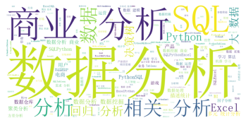

```python
font = r'C:\Windows\Fonts\simsun.ttc'
wc = WordCloud(background_color='white',  #背景设置为白色
               width=1300, height=620,
               font_path=font,
              max_font_size=1000) #这里要设置字体不然显示不出来
wordcloud = wc.generate(cut_text)
plt.imshow(wordcloud)
plt.axis('off') # 不显示坐标
plt.show()
```

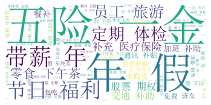

```python
text = ' '.join(data['描述'])
cut_text = ' '.join(jieba.cut(text, cut_all=False, HMM=True))
font = r'C:\Windows\Fonts\simsun.ttc'
wc = WordCloud(background_color='white',  #背景设置为白色
               width=1300, height=620,
               font_path=font,
              max_font_size=1000) #这里要设置字体不然显示不出来
wordcloud = wc.generate(cut_text)
plt.imshow(wordcloud)
plt.axis('off') # 不显示坐标
plt.show()
```